# rs-WGCNA vs R WGCNA 基准测试报告

真实数据集：乳腺癌 RNA-seq（FPKM，36953 基因 × 56 样本）

## 1. 概述

本报告在**真实转录组数据**上对比纯 Rust 实现的 WGCNA 内核（**rs-WGCNA**）与 R 版 `WGCNA` 包，验证两点：

1. **结果一致性**：两者是否给出相同的模块划分；
2. **性能**：在相同算力下，rs-WGCNA 是否显著提速（R 使用默认 reference-BLAS）。

rs-WGCNA 使用纯 Rust 线性代数库 `faer`（多线程 SIMD），**不依赖系统 BLAS**，端上零配置。

## 2. 数据与方法

**数据**：乳腺癌 RNA-seq 表达矩阵（FPKM），36953 个基因 × 56 个样本，5 个分子亚型。

[output not shown]

**预处理**（两端一致）：`log10(x+1)` 归一化 → 按 MAD 取 top 8000 基因。

**WGCNA 参数**（两端一致）：

| 参数 | 取值 |
| --- | --- |
| power | 6 |
| networkType | unsigned |
| TOMType | signed |
| TOMDenom | min |
| minModuleSize | 30 |
| mergeCutHeight | 0.25 |
| deepSplit | 2 |
| detectCutHeight | 0.995 |

**运行环境**：Apple M2（8 核）；rs-WGCNA 用 faer 8 线程，R 用默认 `libRblas`（reference BLAS，单线程）。

## 3. 结果一致性（Parity）

| 检查项 | 结果 |
| --- | --- |
| 过滤后基因集（MAD top 8000） | 100% 一致 |
| 动态切树 cutreeDynamic 标签 | 100% 一致（8000/8000） |
| 最终模块颜色分配 | 8000/8000（100.00%） |

## 4. 模块检测结果

最终得到 **6 个共表达模块 + 1 个 grey（未分配）模块**：

| 模块 | 基因数 |
| --- | --- |
| turquoise | 3197 |
| blue | 2277 |
| grey | 2073 |
| brown | 195 |
| yellow | 102 |
| green | 85 |
| red | 71 |

**模块-性状关联**（模块 eigengene 与亚型的 Pearson 相关）：

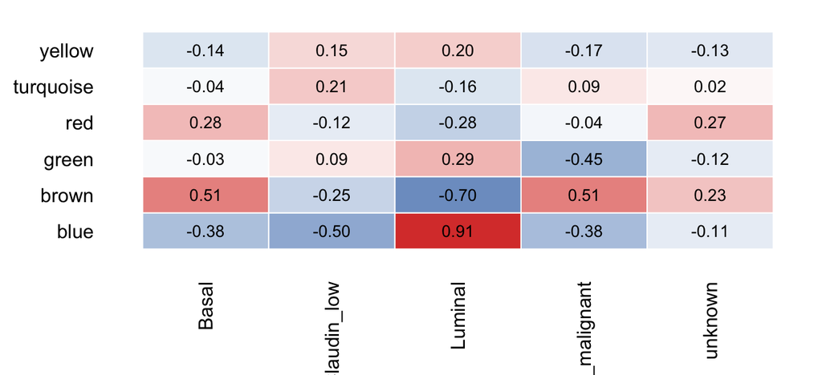

- **blue 模块** 与 **Luminal 亚型** 强正相关（r = 0.91，p < 1e-10）；
- **brown 模块** 与 **Basal**（r = 0.51）及 **Non_malignant**（r = 0.51）正相关。

## 5. 性能基准

| 步骤 | R秒 | Rust秒 | 加速 |
| --- | --- | --- | --- |
| 相关矩阵 cor | 1.202 | 0.084 | 14.4 |
| log10 归一化 | 1.571 | 0.076 | 20.7 |
| MAD top 8000 | 1.014 | 0.044 | 23.0 |
| 模块检测(总) | 116.662 | 11.515 | 10.1 |
| 模块-性状 | 0.112 | 0.013 | 8.5 |
| TOM | 109.969 | 6.758 | 16.3 |

端到端（预处理 + 完整 WGCNA 管线）总耗时：

```
**R 端到端 119.4 秒 vs rs-WGCNA 端到端 11.6 秒，整体加速 10.2 倍**。
```

[figure not shown]

关键瓶颈 **TOM**（拓扑重叠矩阵，O(G³)）：R 用单线程 reference-BLAS 耗时 ~110 秒， rs-WGCNA 用 faer 多线程耗时 ~6.8 秒，**加速约 16 倍**。